# Analyzing diabetes prevalence

### Question

The following dataset contains medical and demographic data from a patient population. The focus of the analysis will be around the prevalence of the diabetes in the patient population and the correlation to certain medical parametes. The broad question I am interested in is which patient demographics are largely affected by diabetes? Also, which medical parameters are strongly associated with diabetes prevalence?

### Data Preview

We will begin by reading in and assigning our csv file into a data frame. From there we will preview the first few rows of data to get an idea of the categories that we are provided.

```r
#loading tidyverse library which contains readr, ggplot that will be used to read in and visualize the data, respectively
library(tidyverse)
#assign csv file to a data frame titled "df"
df <- read.csv("diabetes_prediction_dataset.csv")

#generate first few rows to get an idea of what data contains
head(df)
```

|  | gender | age | hypertension | heart_disease | smoking_history | bmi | HbA1c_level | blood_glucose_level | diabetes |
| --- | --- | --- | --- | --- | --- | --- | --- | --- | --- |
| 1 | Female | 80 | 0 | 1 | never | 25.19 | 6.6 | 140 | 0 |
| 2 | Female | 54 | 0 | 0 | No Info | 27.32 | 6.6 | 80 | 0 |
| 3 | Male | 28 | 0 | 0 | never | 27.32 | 5.7 | 158 | 0 |
| 4 | Female | 36 | 0 | 0 | current | 23.45 | 5.0 | 155 | 0 |
| 5 | Male | 76 | 1 | 1 | current | 20.14 | 4.8 | 155 | 0 |
| 6 | Female | 20 | 0 | 0 | never | 27.32 | 6.6 | 85 | 0 |

```r
NA
```

Let’s find out the total number of rows and columns

```r
#assigning total number of rows and columns to dimensions variable
dimensions <- dim(df)
#total number of rows
num_rows<-dimensions[1]
print(paste("Total number of Rows: ", num_rows))
```

```
[1] "Total number of Rows:  100000"
```

```r
#total number of columns
num_columns <- dimensions[2]
print(paste("Total number of Columns: ", num_columns))
```

```
[1] "Total number of Columns:  9"
```

## Rationale for data manipulation

Because HbA1c levels are usually high in people with diabetes, I’m going to filter out data from patients with Hb1AC levels and prepare a data frame to be plotted

```r
#let's start by checking for NA values in the Hb1ac column

na_values_hb <- is.na(df$HbA1c_level)
num_na_values <- sum(na_values_hb)

print(paste("Total Number of NA Values in HbA1c column: ",num_na_values))
```

```
[1] "Total Number of NA Values in HbA1c column:  0"
```

```r
#now let's check for na values in other parameters we wish to compare

na_values_db <- is.na(df$diabetes)
num_na_values1 <- sum(na_values_db)

print(paste("Total Number of NA Values in Diabetes column: ",num_na_values1))
```

```
[1] "Total Number of NA Values in Diabetes column:  0"
```

```r
na_values_age <- is.na(df$age)
num_na_values2 <- sum(na_values_age)

print(paste("Total Number of NA Values in Age column: ",num_na_values2))
```

```
[1] "Total Number of NA Values in Age column:  0"
```

```r
na_values_gen <- is.na(df$gender)
num_na_values3 <- sum(na_values_gen)

print(paste("Total Number of NA Values in gender column: ",num_na_values3))
```

```
[1] "Total Number of NA Values in gender column:  0"
```

Just interested in seeing what the column names are

```r
colnames(df)
```

```
[1] "gender"              "age"                 "hypertension"
[4] "heart_disease"       "smoking_history"     "bmi"
[7] "HbA1c_level"         "blood_glucose_level" "diabetes"
```

```r
#also highest Level for plotting purposes

biggest <- max(df$HbA1c_level)
print(biggest)
```

```
[1] 9
```

Now we can make a plot

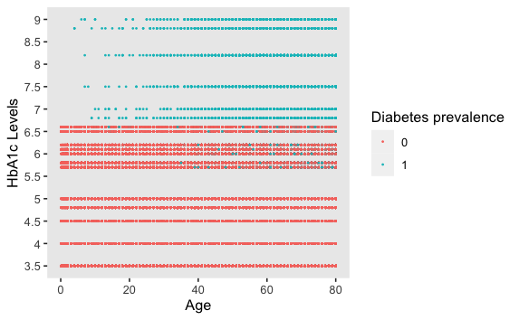

```r
ggplot(data = df, aes(x = age, y = HbA1c_level, color = factor(diabetes))) + geom_point(size = 0.2)+
  labs(x = "Age", y = "HbA1c Levels", color = "Diabetes prevalence") +
  theme(panel.grid = element_blank()) +
  scale_y_continuous(breaks = seq(0, 10, by = 0.5), labels = seq(0, 10, by = 0.5))
```

```r
# Check unique values in columns
unique(df$gender)
```

```
[1] "Female" "Male"   "Other"
```

```r
unique(df$HbA1c_level)
```

```
 [1] 6.6 5.7 5.0 4.8 6.5 6.1 6.0 5.8 3.5 6.2 4.0 4.5 9.0 7.0 8.8 8.2
[17] 7.5 6.8
```

```r
unique(df$diabetes)
```

```
[1] 0 1
```

Not the most visibly pleasing. So I’ll make another plot that might make more sense

[figure not shown]

```r
df_filtered <- df[complete.cases(df[, c("gender", "HbA1c_level", "diabetes")]), ]


# Create the grouped column plot
ggplot(data = df_filtered, aes(x = gender, y = HbA1c_level, fill = factor(diabetes))) +
  geom_col(position = "dodge") +
  labs(x = "Gender", y = "HbA1c Levels", title = "Diabetes prevalence between genders", fill = "Diabetes Status") +
  scale_x_discrete(labels = c("Male", "Female", "Other")) +
  scale_y_continuous(limits = c(0, max(df_filtered$HbA1c_level) + 10)) +
  theme(panel.grid = element_blank()) +
  scale_fill_manual(values = c("0" = "blue", "1" = "red"))
```

My current concern is that the data isn’t as variable as I thought. The data looks too uniform, so I suspect it is not actual patient data.

Let’s do one more plot

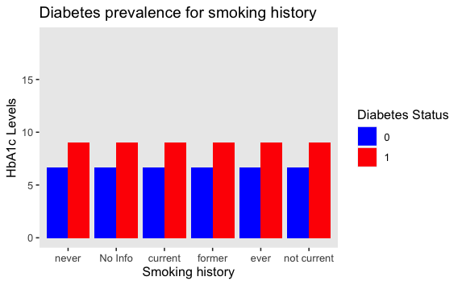

Thank you